# 单变量分析

# 双变量绘图选择

### 各参数与质量的关系程度

```
## [1] "X 0.0664526083970855"
## [1] "fixed.acidity 0.124051649113224"
## [1] "volatile.acidity -0.390557780264007"
## [1] "citric.acid 0.226372514318041"
## [1] "residual.sugar 0.0137316373400663"
## [1] "chlorides -0.128906559930053"
## [1] "free.sulfur.dioxide -0.0506560572442764"
## [1] "total.sulfur.dioxide -0.185100288926538"
## [1] "density -0.174919227783349"
## [1] "pH -0.0577313912053821"
## [1] "sulphates 0.251397079069261"
## [1] "alcohol 0.476166324001136"
## [1] "quality 1"
```

首先列出所有变量与质量之间的关系，可以看出alcohol，volatile.acidity和sulphates排列前3, 所以就针对这3个变量分析。

### 硫酸盐与质量的关系

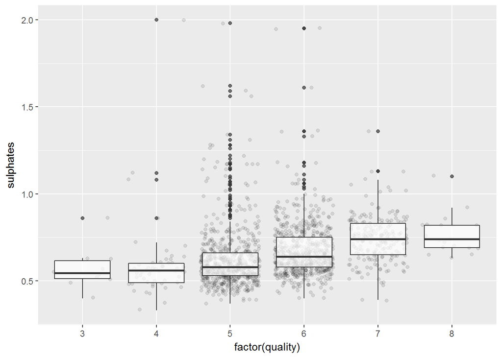

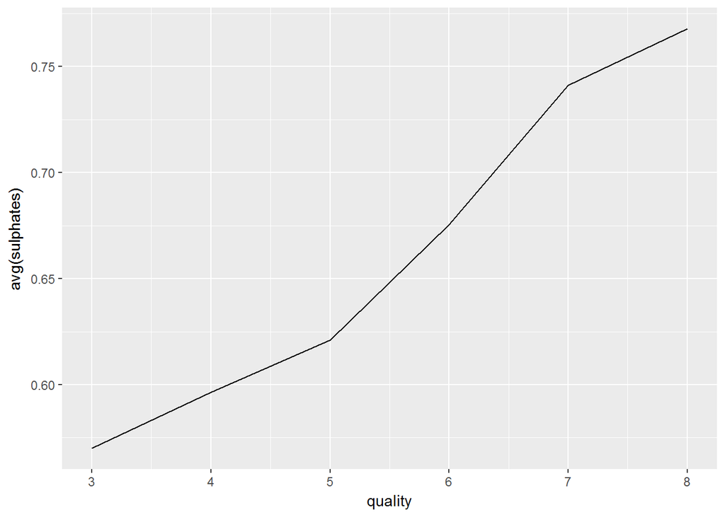

折线图明显的展示了硫酸盐对提升质量有显著帮助，可以看出3类红酒与8类红酒硫酸盐含量的巨大差异。但在箱线图中，这种差异表现的并不明显。在点阵图中，高档酒的硫酸盐含量普遍高于低档，但差异不大。所以结论是硫酸盐与质量有正相关。

### 挥发酸与质量的关系

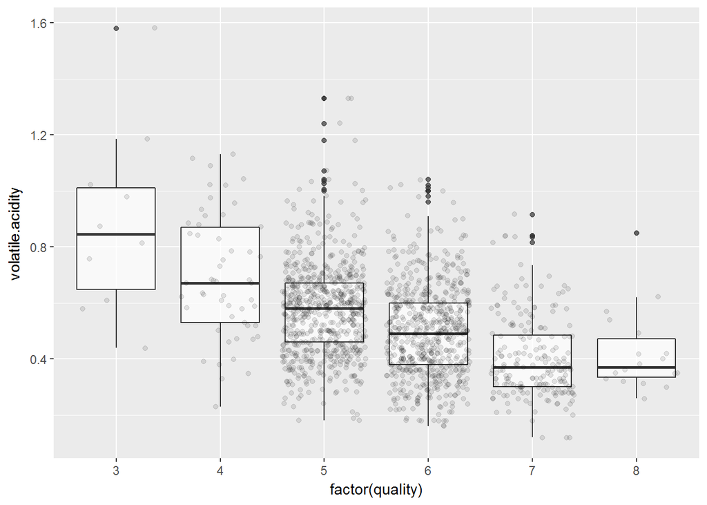

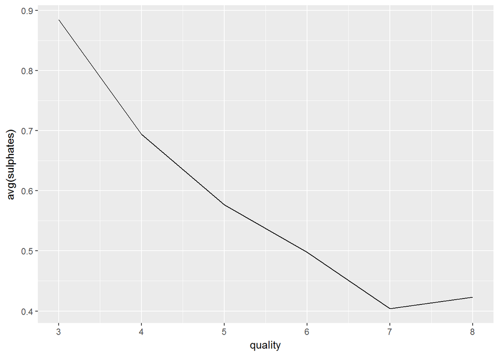

从图中可以看出除了7和8类出现了增长，总的相关趋势是呈负相关。可以理解为质量鉴定是一种主观行为，7类和8类都属于高档类红酒。当参数到达一定程度时，对总体的影响忽略不计。而更多是其他因素的影响

### 酒精与质量的关系

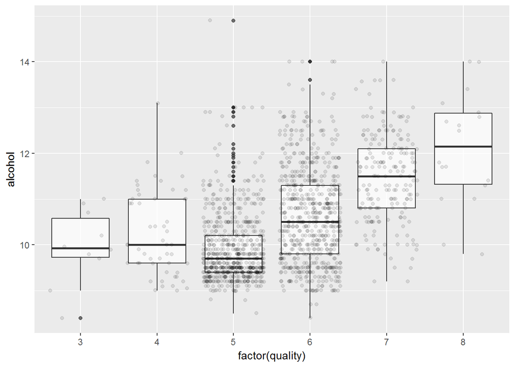

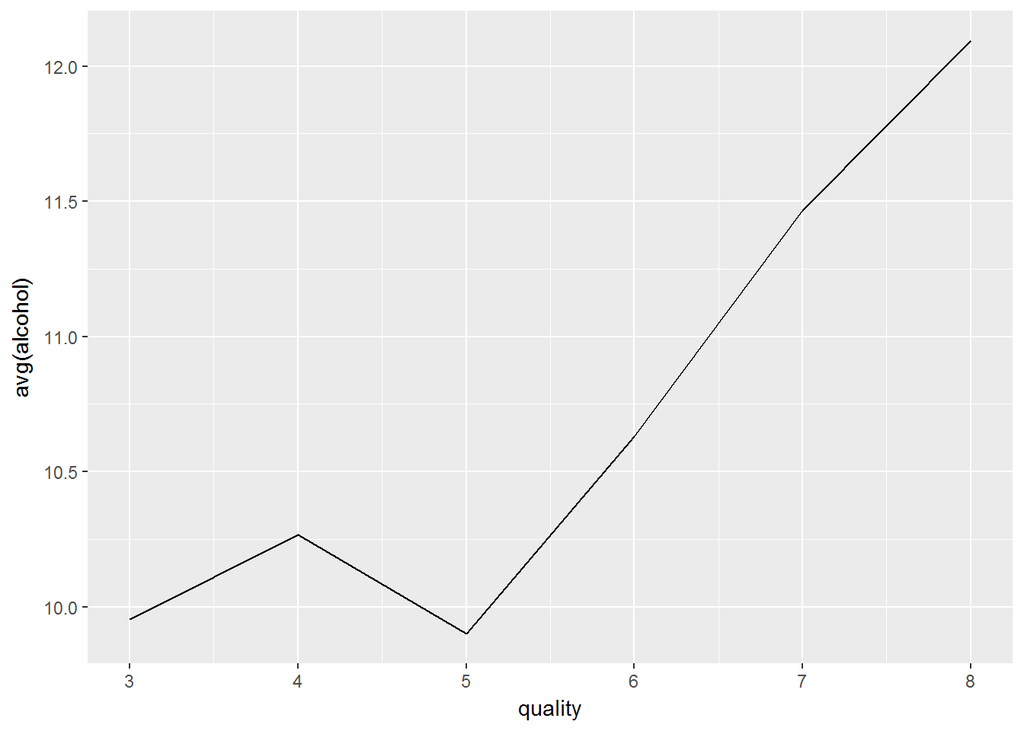

观察这3幅图，点图显示，随着质量的提升，点阵有上移趋势。再看折线图，除了5类红酒外，酒精平均含量与质量总体呈正相关关系。这可能是由于异常值过多导致。所以可以确定，酒精浓度与红酒质量有直接关系。

### 三种酸与pH值的关系

```
##
##  Pearson's product-moment correlation
##
## data:  wine$fixed.acidity and wine$pH
## t = -37.366, df = 1597, p-value < 2.2e-16
## alternative hypothesis: true correlation is not equal to 0
## 95 percent confidence interval:
##  -0.7082857 -0.6559174
## sample estimates:
##        cor
## -0.6829782
```

```
##
##  Pearson's product-moment correlation
##
## data:  wine$volatile.acidity and wine$pH
## t = 9.659, df = 1597, p-value < 2.2e-16
## alternative hypothesis: true correlation is not equal to 0
## 95 percent confidence interval:
##  0.1880823 0.2807254
## sample estimates:
##       cor
## 0.2349373
```

```
##
##  Pearson's product-moment correlation
##
## data:  wine$citric and wine$pH
## t = -25.767, df = 1597, p-value < 2.2e-16
## alternative hypothesis: true correlation is not equal to 0
## 95 percent confidence interval:
##  -0.5756337 -0.5063336
## sample estimates:
##        cor
## -0.5419041
```

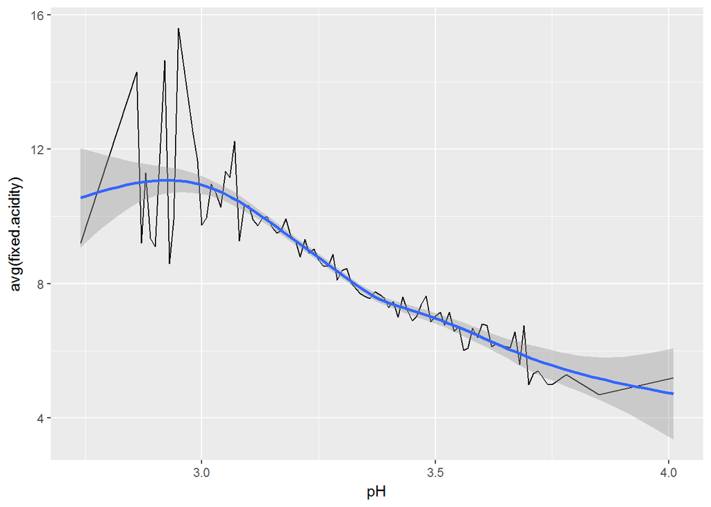

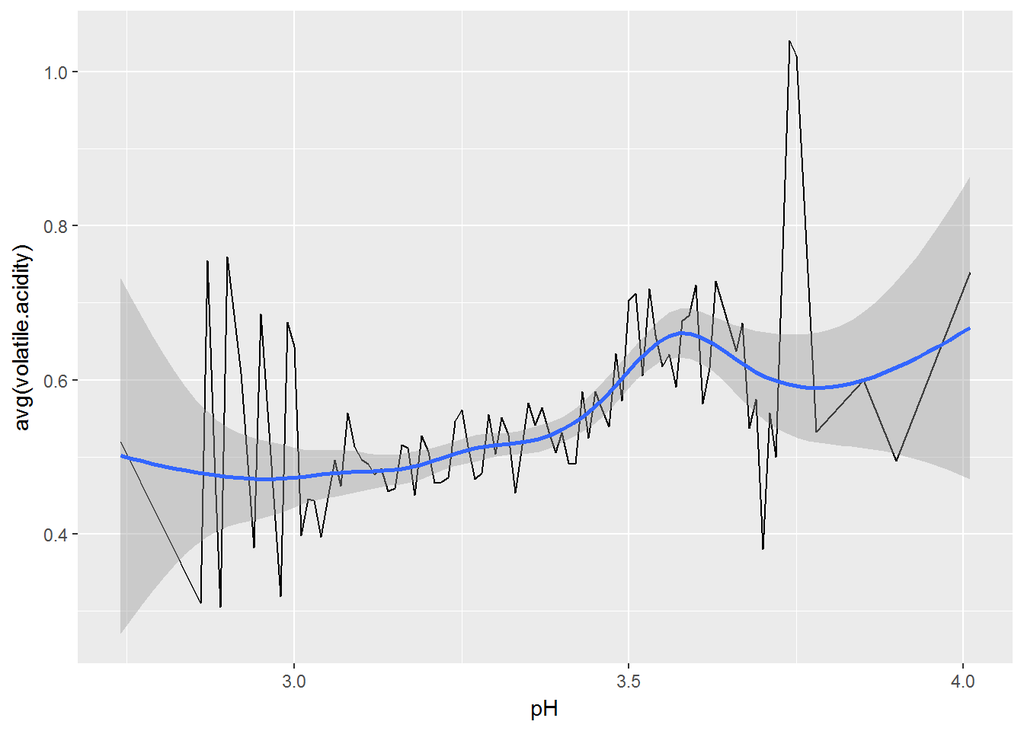

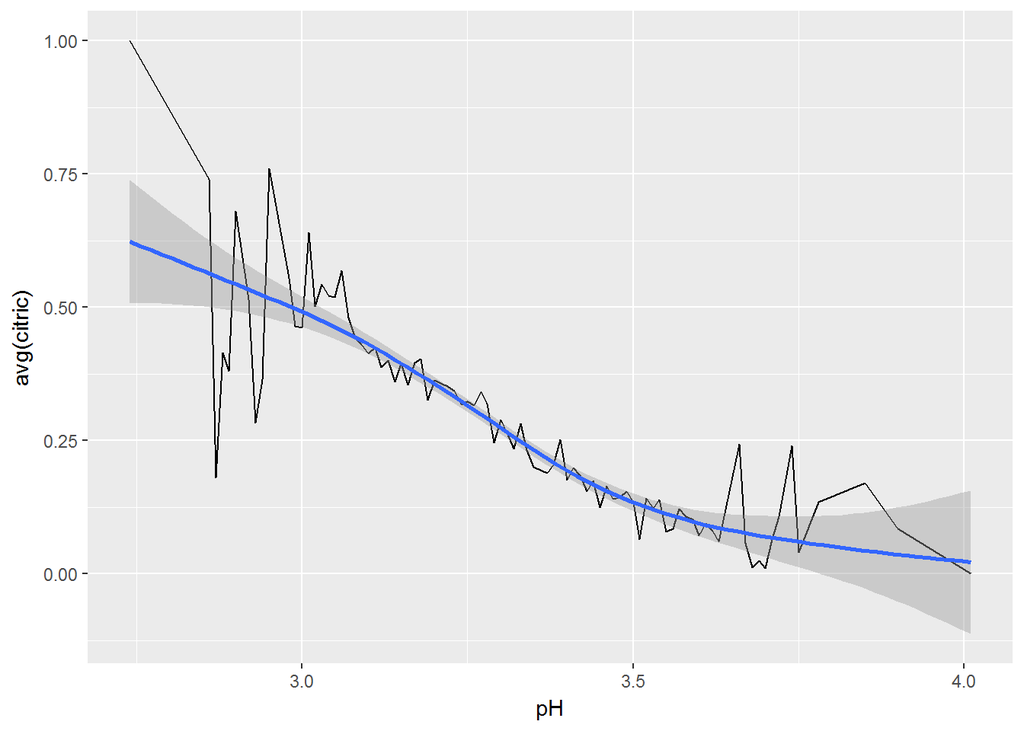

# 双变量分析

### 探讨你在这部分探究中观察到的一些关系。这些感兴趣的特性与数据集内其他特性有什么区别？

挥发酸却pH值呈正比关系，按理说酸性越大ph值越低。可能红酒中采用的挥发性酸酸性较弱，低于酸性平均值。

### 你是否观察到主要特性与其他特性之间的有趣关系？

主要特性设为质量。质量与alcohol和sulphates有正相关，与volatile.acidity有负相关。与糖含量的关联最低，与酒精含量关系最高。

### 你发现最强的关系是什么？

酒精浓度与质量的关系。酒精含量直接影响质量。

# 多变量绘图选择

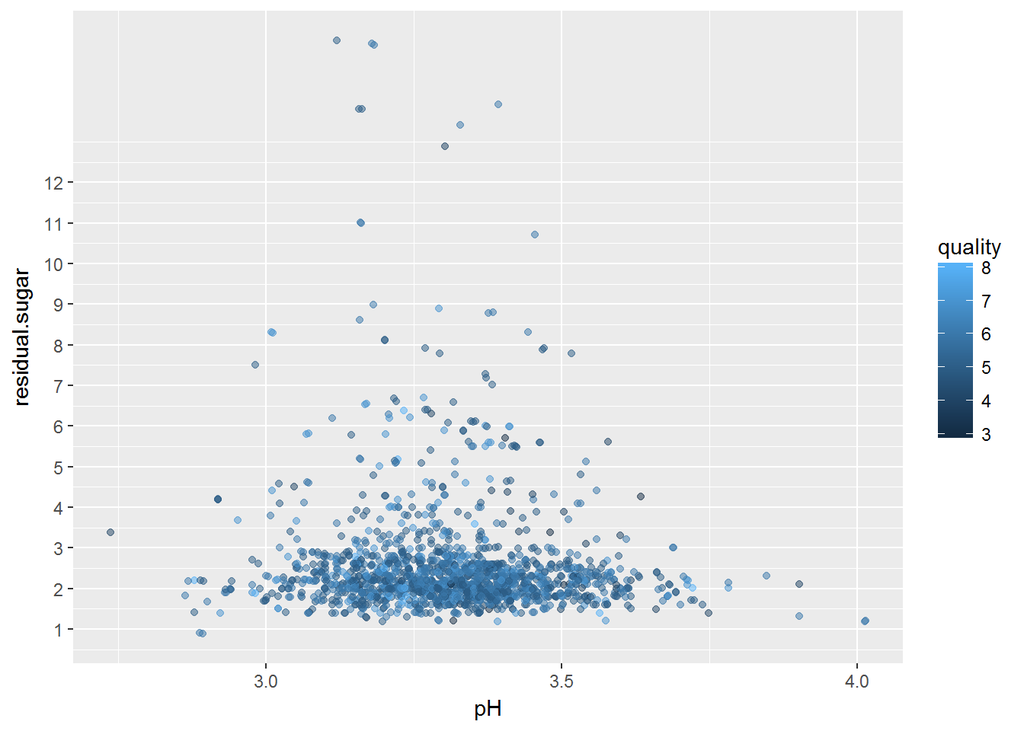

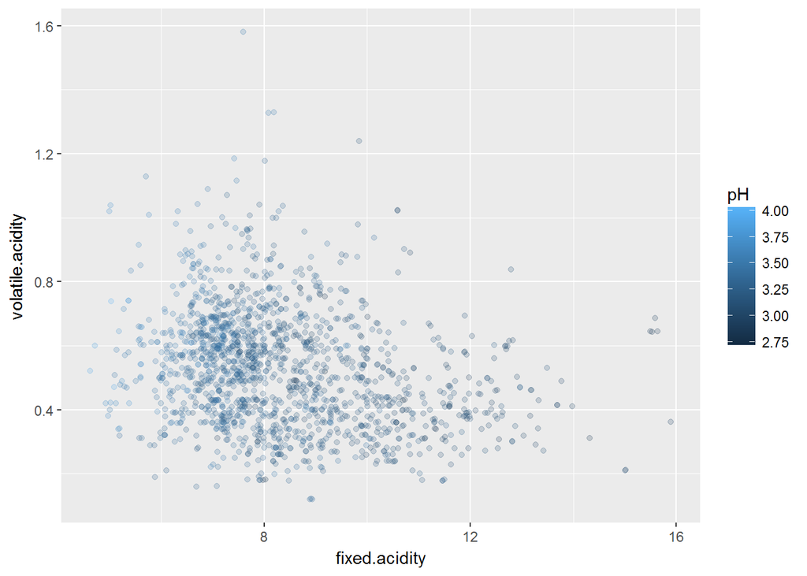

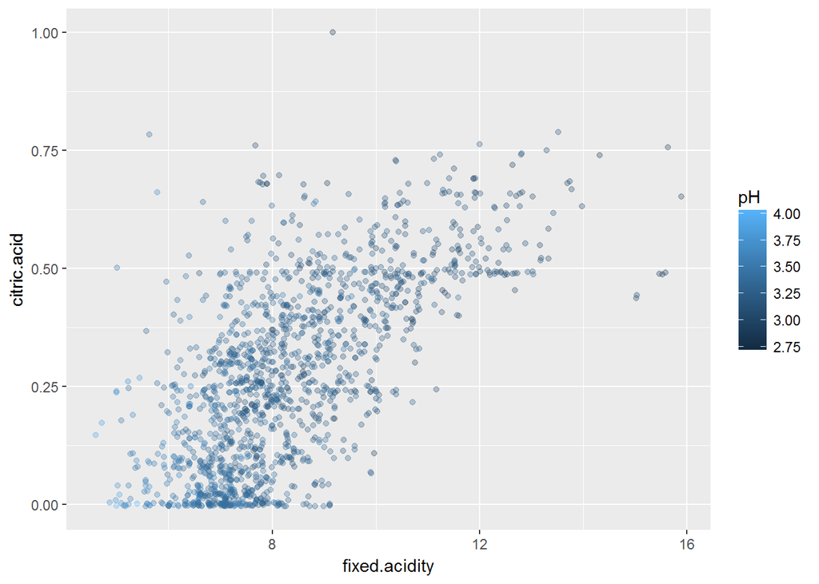

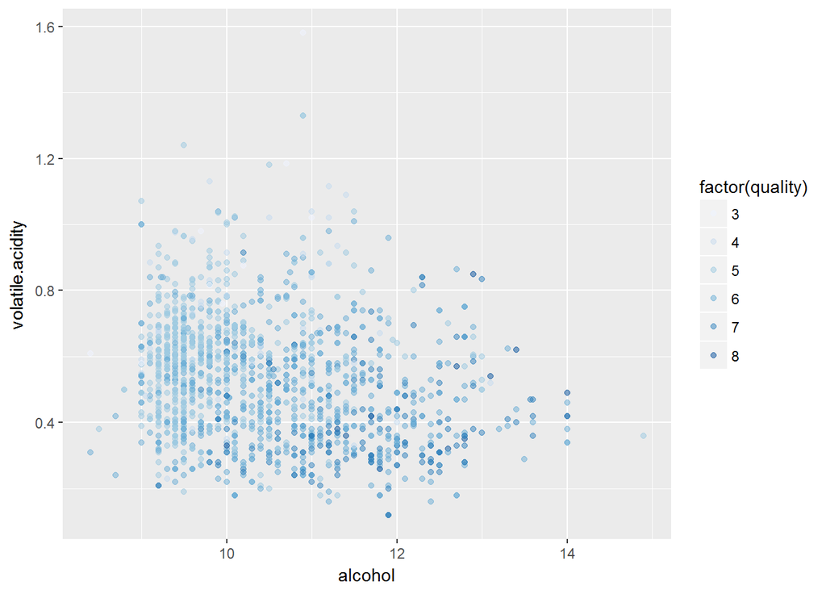

# 多变量分析

### 探讨你在这部分探究中观察到的一些关系。通过观察感兴趣的特性，是否存在相互促进的特性？

糖和pH值没有可见的影响，事实上这2个值表现的非常集中，糖分大部分在1-3之间，而pH值在3-3.5之间。猜测在酿造过程中，这2个值是可控的。

### 这些特性之间是否存在有趣或惊人的联系呢？

1. pH值和糖对质量影响不大。
2. 固定酸在pH值中起主要作用。是调节酸性的主要成分。

### 选项：你是否创建过数据集的任何模型？讨论你模型的优缺点。

# 定稿图与总结

### 绘图一

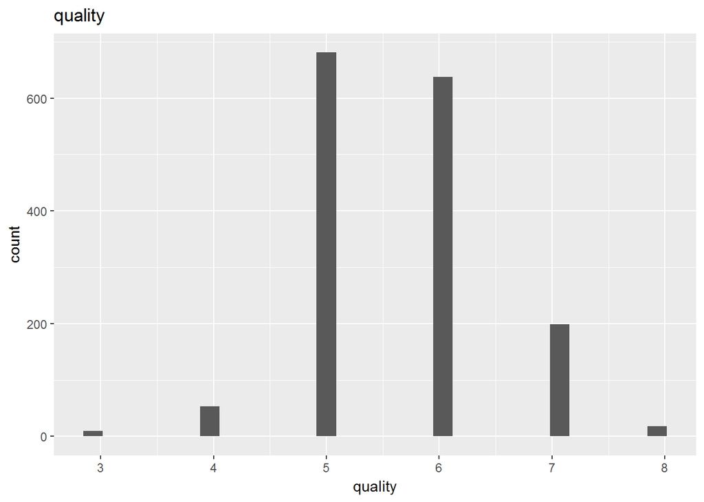

### 描述一

样本中3～4类（劣质）和7～8类酒（优质）都是少数，5～6类酒占多数量。相比之下，优质酒的数量还是要多于劣质酒。说明这批酒的质量较好。

### 绘图二

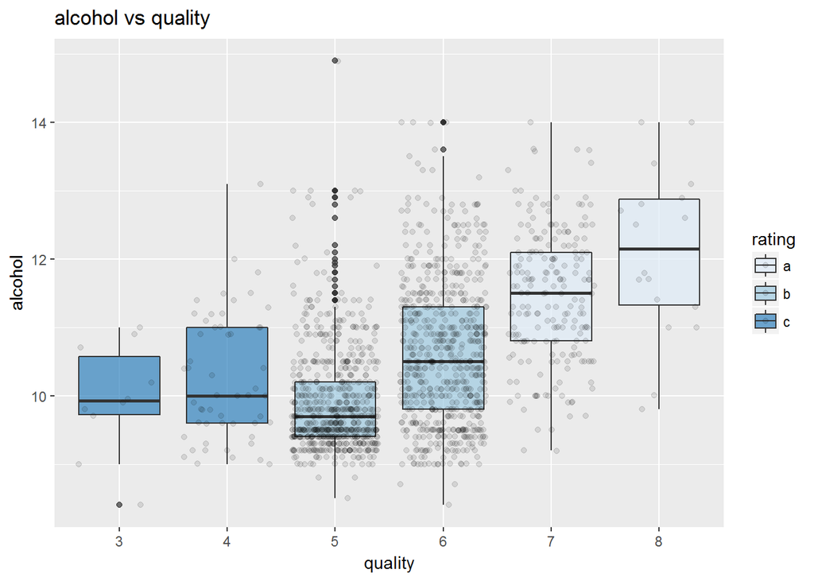

### 描述二

酒精浓度对酒品质有影响，但这种影响在高档酒上表现的比较突出。而在中低端酒上，则不怎么明显。

### 绘图三

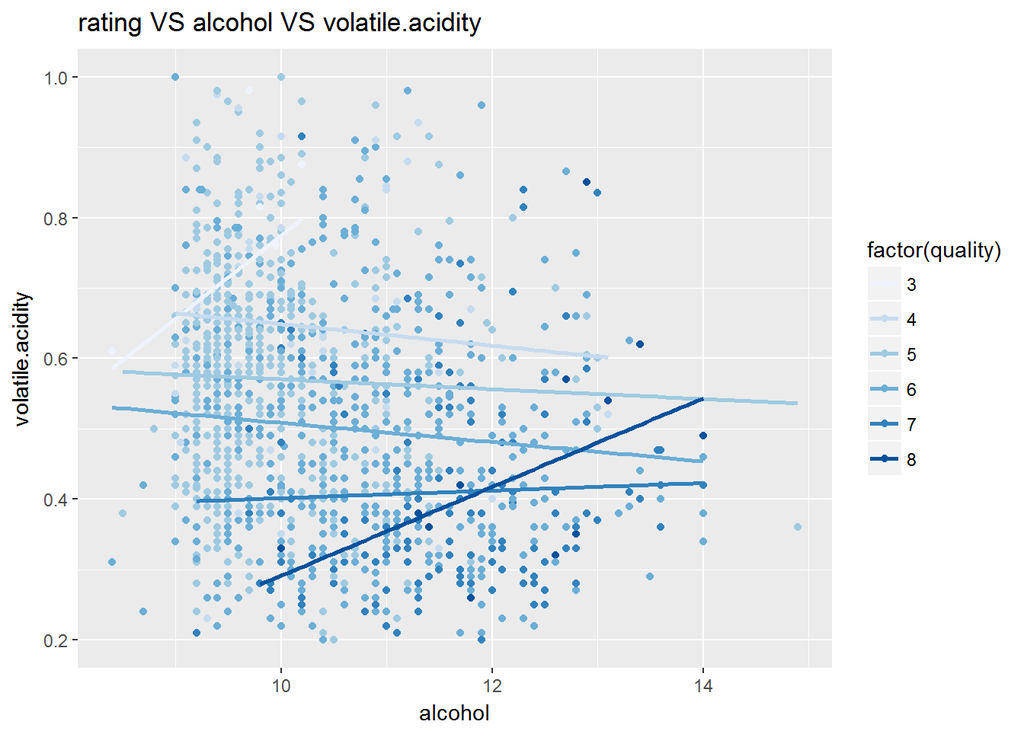

### 描述三

去掉离散值后，将酒精和挥发酸组合起来查看对质量的影响.在酒精含量较低的状态下，挥发酸含量越低等级越高，但随着酒精含量的上升，挥发酸的因素变得不再重要。所以结论是低质酒减少挥发酸能改善质量，而要成为优质，必须保证酒精含量。

# 反思

提议： 可以加入酒的生产过程中的一些数据，比如产地，发酵情况和存放时间。这样综合起来就能对酒内成分的产生原因，比如酒精浓度有更深入的分析。